# Cleveland Indians Game Duration

ARIMA

Michael Foley

2021-11-07

Autoregressive integrated moving average (ARIMA) models describe the autocorrelation in time series data. (See my [handbook](https://bookdown.org/connect/#/apps/67b5716a-6cdd-4892-935c-d6860310432b/access)).

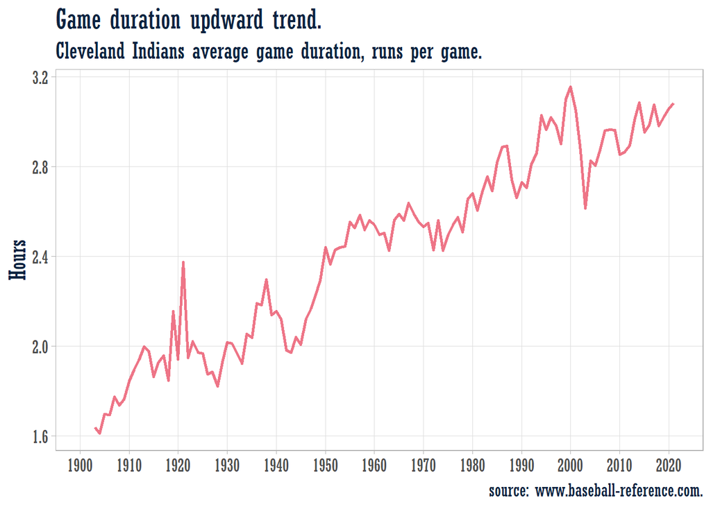

## Fit Model

A good first start is to allow the algorithm to select which model is optimal.

```
## Series: game_hrs9
## Model: ARIMA(1,1,0) w/ drift
##
## Coefficients:
##           ar1  constant
##       -0.4095    0.0174
## s.e.   0.0834    0.0089
##
## sigma^2 estimated as 0.009434:  log likelihood=108.62
## AIC=-211.24   AICc=-211.03   BIC=-202.93
```

ARMIA chose an ARIMA(1, 1, 0) model.

$$y'_t = c + \phi_1 y'_{t-1} + \dots + \phi_p y'_{t-p} + \theta_1 \epsilon_{t-1} + \theta_2 \epsilon_{t-2} + \dots + \theta_p \epsilon_{t-q} + \epsilon_t$$

The first part of the equation says the forecasted observation is a function of the last *p* = 1 observations with a drift (slope) equal to *c*. The second part of the equation says the model is a function of the last *q* = 0 observation’s estimation error. The prime in $y'_t$ means the model measures the first difference in observations, that is the *change* in observed values rather than the level.

The fitted to actuals plot has a good linear relationship.

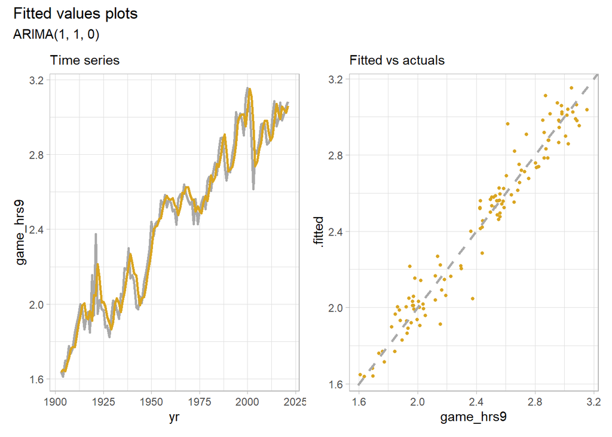

## Model Evaluation

Evaluate the regression model with diagnostic plots. Use `feasts::gg_tsresiduals()` from the tidyverts.

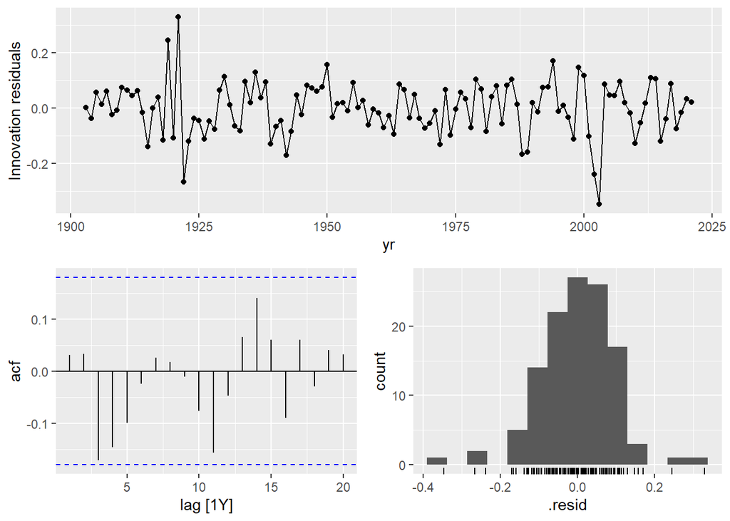

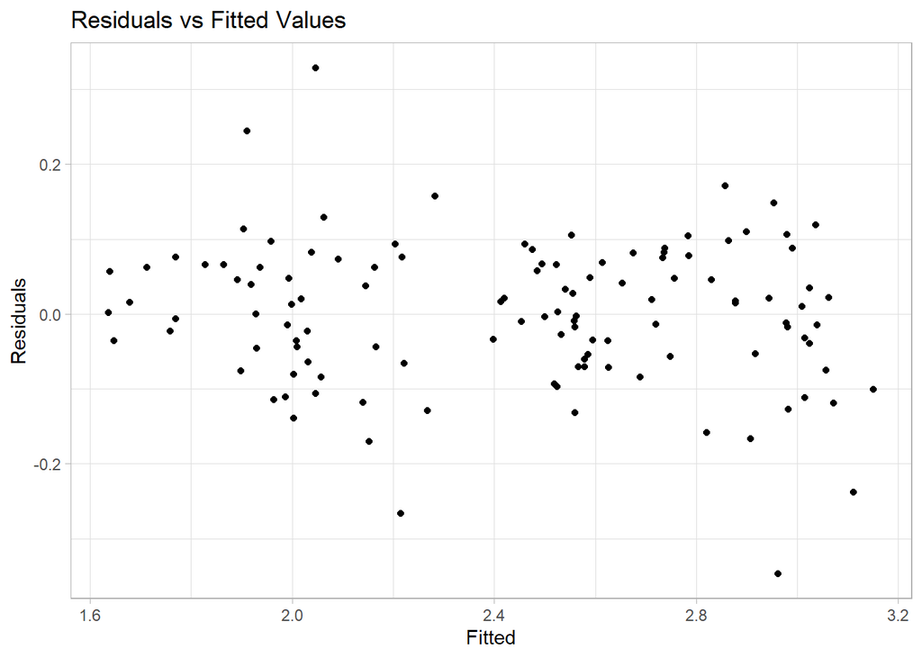

## Predicting Values

Use the model to forecast game durations over the next decade.

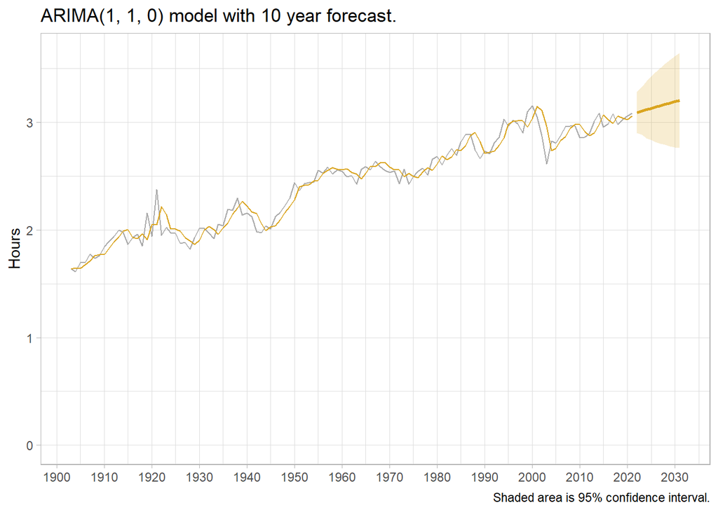

The model predicts game durations to increase to 3:12 by 2031.